# Spatial Analysis in R

### Lesson Plan for Math 378

**Christensen, Soren A., Lo, Rachel Y., Reed, Brian T.**

**21 April 2015**

### Introduction

Spatial Statistics is a statistical method that uses space directly in the mathematical computations. Spatial Statistics uses distance, area, orientation or any other spacial relationships to analyze, predict, or model data sets where space is involved.

The concept of Spatial Statistics seems to have origins in cartography but throughout the year has contributed to botany (plants), ecology (environment), ethology (animal movement), epidemiology (disease), and economics. Today, it is most commonly used for the analysis of geographic data.

Spatial statistics is unique from analytic methods commonly studied in an undergraduate-level statistics course. The differences can be seen by the sheer number of difference in fundamental approach, forms of data, and fields of applicable research.

### Objectives

Introduce this area of statistics to class, give them exposure.

Be familiar to applications of the package.

Talk briefly about other packages.

Show how this is applicable to being an analyst in the air force.

### Example

One of the most important application of spatial analysis in wildlife tracking is home range estimation. Many mammals restrict their movements to a home range, rarely venturing far. By estimating an animals home range we can investigate what events effect the home range, and how it changes based on time.

For example see how these home ranges change from April to May to June.

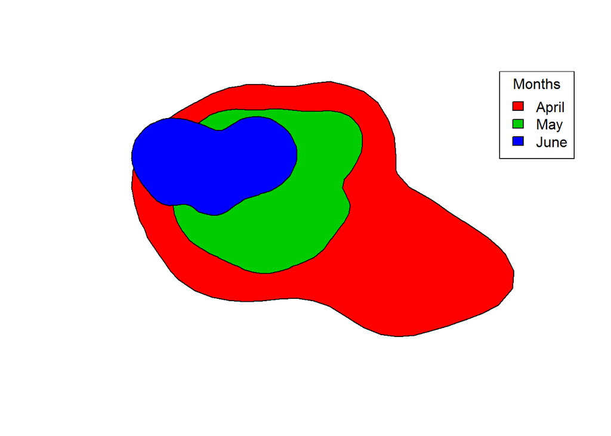

```r
track = read.csv("DeerSample.csv")
track = na.omit(track)

track2 = filter(track, DATETIME >= 40634 & DATETIME <= 40663) #april
track3 = filter(track, DATETIME >= 40664 & DATETIME <= 40694) #may
track4 = filter(track, DATETIME >= 40695 & DATETIME <= 40724) #june

track2S = SpatialPoints(data.frame(track2$LONGITUDE, track2$LATITUDE))
track3S = SpatialPoints(data.frame(track3$LONGITUDE, track3$LATITUDE))
track4S = SpatialPoints(data.frame(track4$LONGITUDE, track4$LATITUDE))

track2K = kernelUD(track2S)
track3K = kernelUD(track3S)
track4K = kernelUD(track4S)

track2H = getverticeshr(track2K)
track3H = getverticeshr(track3K)
track4H = getverticeshr(track4K)

plot(track2H,col = 2)
plot(track3H,col = 3, add = T)
plot(track4H,col = 4, add = T)

legend("topright", title="Months", c("April","May","June"), fill=c(2,3,4), horiz=F)
```

The home range varies so much because female deer give birth in late May or early June.The deer is very active in April because she is eating for two, she moves around a lot to find sufficient nourishment. This deer most likely gave birth in late may, which is why the home range is smaller, but not as small as in June. In June the deer has given birth to a new fawn, which limits its movements.

Some methods for calculating home ranges calculates them based off a percentile. One such method is the minimum convex polygon. This method creates the smallest possible convex home range which includes all the points in a certain percentile. These percentiles can be thought of as containing the percent of points which are closest to the center of mass of the entire distribution.

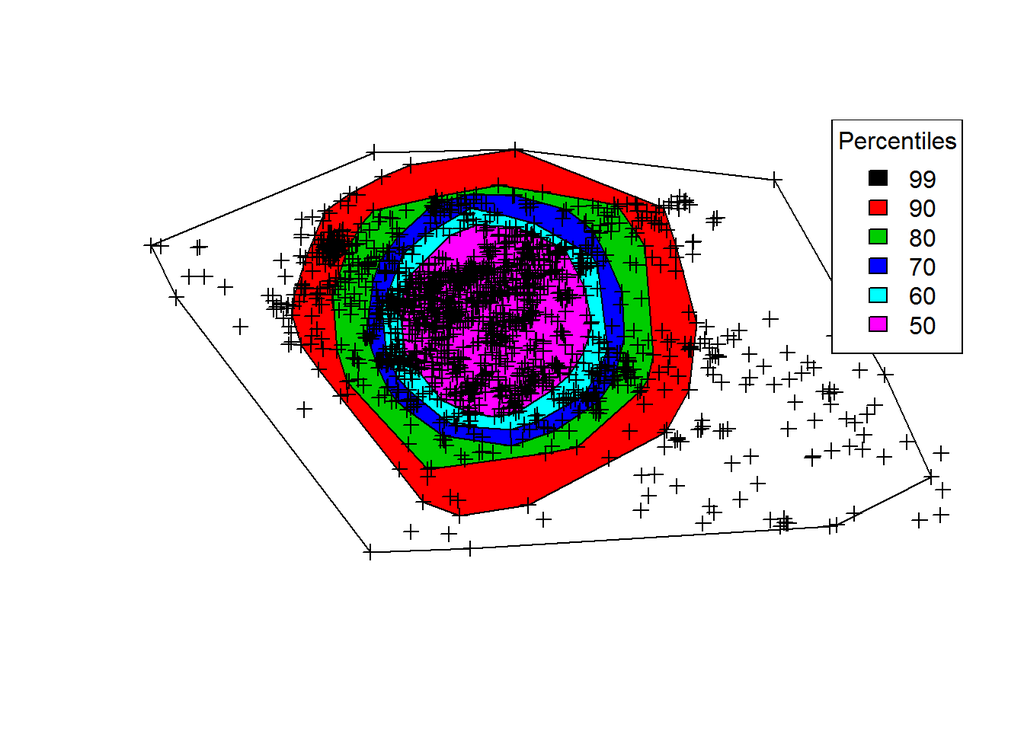

```r
trackSp = SpatialPoints(data.frame(track$LONGITUDE, track$LATITUDE))

trackCp = mcp(trackSp, percent = 99)
track90C = mcp(trackSp, percent = 90)
track80C = mcp(trackSp, percent = 80)
track70C = mcp(trackSp, percent = 70)
track60C = mcp(trackSp, percent = 60)
track50C = mcp(trackSp, percent = 50)

plot(trackCp)
plot(track90C, add = T, col = 2)
plot(track80C, add = T, col = 3)
plot(track70C, add = T, col = 4)
plot(track60C, add = T, col = 5)
plot(track50C, add = T, col = 6)
plot(trackSp, add = T)

legend("topright", title="Percentiles", c("99","90","80","70","60","50"), fill=c(1,2,3,4,5,6), horiz=F)
```

Thus far we have approached the data set as a set of independent points, but we know this is not true.If we look at the data set we imported we can see that it contains several other variables.

```r
head(track)
```

```
##   LINE_NO LATITUDE LONGITUDE DATETIME  HEIGHT Collar_ID TEMP
## 1       7 38.96511 -104.7200 40536.00 2085.15      2925   12
## 2      21 38.98689 -104.8853 40542.50 2109.06      2925    8
## 3      22 38.99153 -104.8809 40542.75 2102.16      2925   -6
## 4      23 38.98976 -104.8835 40543.00 2114.72      2925  -10
## 5      24 38.98973 -104.8834 40543.25 2112.11      2925  -11
## 6      25 38.98979 -104.8823 40543.50 2085.50      2925   -5
```

```r
track1 = filter(track, DATETIME >= 40604 & DATETIME <= 40633)
trans1 = as.ltraj(xy = cbind(track1$LONGITUDE, track1$LATITUDE), date = as.POSIXct(track1$DATETIME  *60 * 60 *24, origin="1899-12-30"), id = "Deer")
head(trans1[[1]])
```

```
##           x        y                date         dx         dy
## 1 -104.8815 38.98385 2011-03-01 17:00:00  0.0001993  0.0004019
## 2 -104.8813 38.98425 2011-03-01 23:00:00  0.0018437  0.0016721
## 3 -104.8795 38.98593 2011-03-02 05:00:00 -0.0050300  0.0045727
## 4 -104.8845 38.99050 2011-03-02 11:00:00 -0.0006998 -0.0018630
## 5 -104.8852 38.98864 2011-03-02 17:00:00 -0.0038271 -0.0025521
## 6 -104.8890 38.98608 2011-03-03 05:00:00  0.0009999  0.0003979
##           dist    dt          R2n  abs.angle  rel.angle
## 1 0.0004486024 21600 0.000000e+00  1.1104385         NA
## 2 0.0024890054 21600 2.012441e-07  0.7366286 -0.3738099
## 3 0.0067978295 21600 8.475325e-06  2.4037806  1.6671519
## 4 0.0019900977 21600 5.310079e-05 -1.9301198  1.9492849
## 5 0.0045999901 43200 3.647628e-05 -2.5534634 -0.6233436
## 6 0.0010761619 21600 6.143873e-05  0.3787291  2.9321925
```

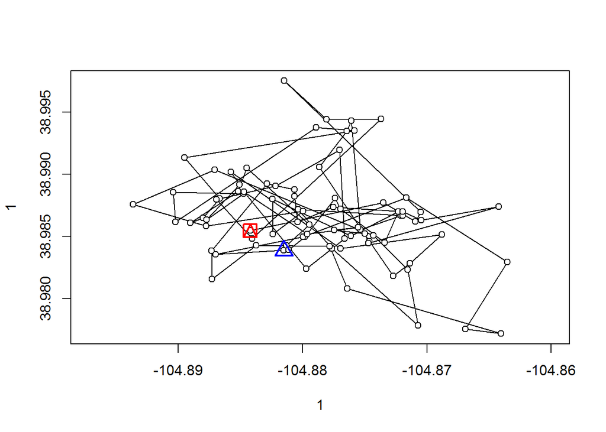

```r
plot(trans1)
```

We can see how the distance between points varries in the month of June.

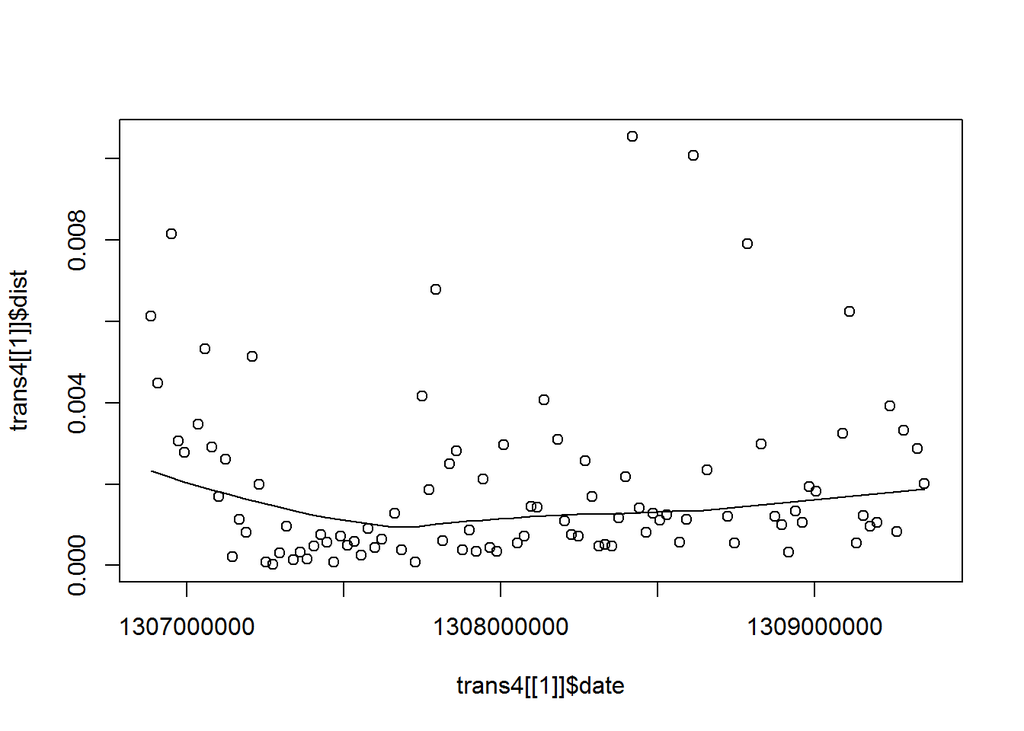

```r
trans4 = as.ltraj(xy = cbind(track4$LONGITUDE, track4$LATITUDE), date = as.POSIXct(track4$DATETIME  *60 * 60 *24, origin="1899-12-30"), id = "Deer")

scatter.smooth(trans4[[1]]$date, trans4[[1]]$dist)
```

We see that the trend sharply decreases near the beginning of the month and then steadily increases. The dip is most likely representative of the birth of a fawn.

### Readings

Materials for the students to review before class, and use as references while doing the homework.

An brief article which addresses the importance of spatial analysis in the world. This is important for the students to understand why this topic is being addressed.

http://www.nytimes.com/2015/01/09/business/international/mapping-the-worlds-problems.html

This is an introductory vignette for basic exercises using adehabitatHR, as well as one for adehabitatLT.

http://cran.r-project.org/web/packages/adehabitatHR/vignettes/adehabitatHR.pdf http://cran.r-project.org/web/packages/adehabitatLT/vignettes/adehabitatLT.pdf

Main CRAN webpage for adehabtiatHR as well as one for adehabitatLT.

http://cran.r-project.org/web/packages/adehabitatHR/index.html http://cran.r-project.org/web/packages/adehabitatLT/index.html

### Homework Questions (with solutions)

Load the file DeerSample.csv this is a file containing real tracking data from a single deer on the USAFA reservation.

**1. Find the area for the 80% home range in December**

```r
trackDec = filter(track, DATETIME >= 40878.00 & DATETIME <= 40908.00)
trackDecS = SpatialPoints(data.frame(trackDec$LONGITUDE, trackDec$LATITUDE))
mcp(trackDecS, percent = 80)
```

```
## Object of class "SpatialPolygonsDataFrame" (package sp):
##
## Number of SpatialPolygons:  1
##
## Variables measured:
##   id        area
## a  a 7.98762e-09
```

**2. Find the average transect distance for the deer in December**

```r
trackDec = filter(track, DATETIME >= 40878.00 & DATETIME <= 40908.00)
transDec = as.ltraj(xy = cbind(trackDec$LONGITUDE, trackDec$LATITUDE), date = as.POSIXct(trackDec$DATETIME  *60 * 60 *24, origin="1899-12-30"), id = "Deer")

mean(na.omit(transDec[[1]]$dist))
```

```
## [1] 0.004424626
```

**3. Find the average transect distance for the deer in June**

```r
trackJun = filter(track, DATETIME >= 40695 & DATETIME <= 40724)
transJun = as.ltraj(xy = cbind(trackJun$LONGITUDE, trackJun$LATITUDE), date = as.POSIXct(trackJun$DATETIME  *60 * 60 *24, origin="1899-12-30"), id = "Deer")

mean(na.omit(transJun[[1]]$dist))
```

```
## [1] 0.001926358
```

**4. What units are these distances and in?**

Degrees, which does not mean much for us.

**5. How could you convert these units to something that you can understand (requires some research online)?**

We need to convert the degrees from this projection into euclidean distances. One way to do this is to use the package rgdal, which pulls the projection operations from the PROJ.4 library. http://cran.r-project.org/web/packages/rgdal/rgdal.pdf

**6. Why do you think the average distance is different between the two months?**

June is when the female deer give birth, thus they aren’t moving very much. December is their mating season, so they are being chased around by male deer.

**7. What are some different forms of home range estimation (requires some research online)?**

MCP, several kernel methods: classical, brownian, product kernel. Local Convex Hull

### References

Other references that might be useful

https://sites.google.com/site/rodriguezsanchezf/news/usingrasagis

https://www.movebank.org/node/14620

http://www.rdocumentation.org/packages/adehabitat

http://core.ac.uk/download/pdf/26815643.pdf

http://cran.r-project.org/web/packages/adehabitat/adehabitat.pdf

http://www.mikemeredith.net/blog/1212_Data_for_home_range_analysis_in_R.htm#1

http://cran.r-project.org/web/packages/adehabitatHR/vignettes/adehabitatHR.pdf